# Forecasting Daily Data with Multiple Seasonality in R

David Benson

Time series forecasting techniques often presume single seasonality in the data, e.g. only monthly patterns. When forecasting daily data however, there often exists double or multiple seasonality. Examples include daily admissions into hospitals/clinics, daily revenue in retail, hourly usage of internet traffic. This page, demonstrates one smoothing technique and one regression technique for forecasting such data into the near future.

## Daily Admissions into a Respiratory Center

The example data is daily admissions from a respiratory center from the 1st April 2012 until the 31st of March 2016. It can be accessed here. The aim is to forecast this data two weeks into the future.

#### Installing, Loading and Reading

It is first neccessary to install and load the forecast package in R, and read the CSV file (if in correct directory). The lubridate package is also used to easily insert the dates into the time series.

```r
install.packages('forecast')
install.packages('lubridate')
library(forecast)
library(lubridate)
ts <- read.csv("ts.csv")
```

We then want to create a msts object (multiple season time series object). The season 7 and 365.25 are used. 7 is for the weekly pattern, 365.25 is used for the monthly/annual patterns.

```r
msts <- msts(ts$Daily.admissions,seasonal.periods = c(7,365.25),start = decimal_date(as.Date("2012-04-01")))
plot(msts, main="Daily Admissions", xlab="Year", ylab="Daily Admissions")
```

[output not shown]

#### Decomposition

To analyse the seasonality of the data we can extract the components. To do this with multiple seasonal components we can use TBATS.

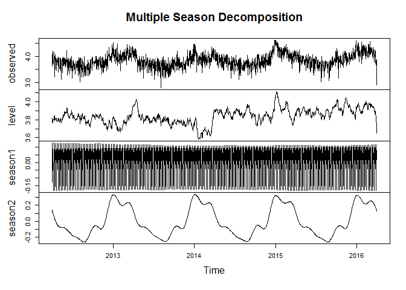

```r
library(forecast)
tbats <- tbats(msts)
plot(tbats, main="Multiple Season Decomposition")
```

### Smoothing Forecast with TBATS

Unlike other techniques such as Holt-Winters, TBATS can forecast using an ‘msts’ object and therefore can accomodate multiple seasonality. This can be seen below.

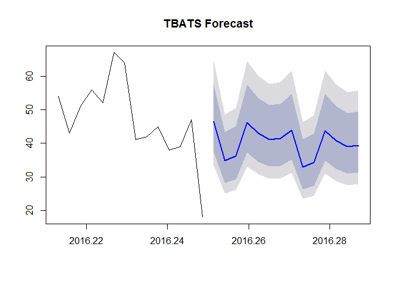

```r
sp<- predict(tbats,h=14)
plot(sp, main = "TBATS Forecast", include=14)
```

```r
print(sp)
```

```
##           Point Forecast    Lo 80    Hi 80    Lo 95    Hi 95
## 2016.2514       46.46176 37.49144 57.56683 33.46410 64.47762
## 2016.2541       34.87669 28.10206 43.27574 25.06394 48.50824
## 2016.2569       36.26811 29.19021 45.05299 26.01887 50.53048
## 2016.2596       46.22916 37.17527 57.47622 33.12126 64.49344
## 2016.2623       42.97796 34.52048 53.49637 30.73694 60.06468
## 2016.2651       41.16846 33.03079 51.30016 29.39343 57.63217
## 2016.2678       41.51951 33.27726 51.79220 29.59617 58.21741
## 2016.2706       43.87183 35.12943 54.77814 31.22781 61.60445
## 2016.2733       32.93744 26.33766 41.18207 23.39541 46.34772
## 2016.2760       34.26605 27.37152 42.88781 24.30035 48.29396
## 2016.2788       43.70628 34.88526 54.74568 30.95829 61.67179
## 2016.2815       40.66385 32.42131 50.99055 28.75499 57.47480
## 2016.2843       38.98898 31.05391 48.94067 27.52717 55.19426
## 2016.2870       39.36608 31.32314 49.46301 27.75121 55.81257
```

### Regression forecast with Dummies

Dummy variables are simply variables that have been categorised into 1’s and 0’s depending on whether the category is present or not. With our data, this would be done by determining the day of the week of each time period and the month of each time period. Each categorised season is divided into separate variables and binary classified (1’s are given when the season is present at an observation, 0 when not). One dummy category is deleted to avoid a negative multicollinearity issue between the dummies.

i.e. For day of the week seasonality, create 6 dummy variables. For day of the month seasonality, create 30 dummy variables. For month of the year, create 11 dummy variables.

If the data exhibits a trend then the trend component should be included.

### Regression forecast in R with ARIMA forecast on the residuals

Using a lot of dummy variables has an issue. Dummies aren’t very flexible to errors and changes in patterns. An alternative approach is to create a simple linear regression and then analyse the residuals.

The residuals of a regression model are the error values; how much the regression model deviates from the actual daily admissions observed. They are the difference between the actual values and the values created from the regression. Adding the residuals to the regression model would give the actual values. Combining the forecast from the regression model with a forecast of the residuals of that same regression model should therefore give a good forecast.

The ‘tslm’ function in R fits a regression to a ‘ts’ object. The daily admissions is the dependent variable and the trend and seasonality are the predictors. The seasonlity in this case is 6 dummy variables of the days of the week which are automatically created in R.

```r
tsw <- ts(ts$Daily.admissions, start = decimal_date(as.Date("2012-04-01")), frequency = 7)
mytslm <- tslm(tsw ~ trend + season)
print(mytslm)
```

```
##
## Call:
## tslm(formula = tsw ~ trend + season)
##
## Coefficients:
## (Intercept)        trend      season2      season3      season4
##   44.603021     0.008198   -11.416851    -9.497710     1.972561
##     season5      season6      season7
##   -2.528459    -3.354839    -2.286481
```

This model alone would be a poor forecasting tool. It ignores the monthly seasonality. We therefore model and forecast the residuals, and combine it with the regression models forecast. To model the residuals we can use any technique. The example below uses auto.arima from the ‘forecast’ package. The printed values are the forecast results for the next two weeks.

```r
residarima1 <- auto.arima(mytslm$residuals)
residualsArimaForecast <- forecast(residarima1, h=14)
residualsF <- as.numeric(residualsArimaForecast$mean)

regressionForecast <- forecast(mytslm,h=14)
regressionF <- as.numeric(regressionForecast$mean)

forecastR <- regressionF+residualsF
print(forecastR)
```

```
##  [1] 44.65989 32.52478 34.24205 45.53235 41.94534 40.85126 41.17629
##  [8] 45.07940 33.64900 36.10451 48.08889 43.34817 43.08154 45.02734
```

### Which forecast model is Best?

Before forecasting it would be useful to determine which model is best. We would then forecast with this model. To compare models, it is necessary to split the data up into training and test sets, and calculate their accuracy rates.

#### Data Partitioning

Partitioning is done by trimming the series into two periods. The earlier period is the training set and the later period is the test set. The usual approach is to use the first 70-80% of the data as the training set and the last 20-30% as the test set. For forecasting daily data a couple weeks into the future, such a large test set would not be suitable. We want to mimic the forecasting task as close as possible. This would involve a test set of two weeks. To avoid overfitting to one individual test set of two weeks, we can use rolling partitions. We can test approximately 20% of the data in 20 partitions of 14 days.

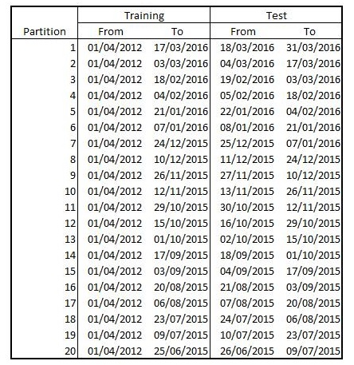

This can be performed in R using a loop. Below is the example for TBATS. (This takes a while to run)

```r
for (i in 1:20)
{ nTest <- 14*i
  nTrain <- length(msts)- nTest
  train <- window(msts,start=decimal_date(as.Date("2012-04-01")),end=c(decimal_date(as.Date("2012-04-01")),nTrain))
  test <- window(msts, start=c(decimal_date(as.Date("2012-04-01")),nTrain+1), end=c(decimal_date(as.Date("2012-04-01")),nTrain+14))

  s <- tbats(train)
  sp<- predict(s,h=14)

  cat("----------------------------------

Data Partition",i,"

Training Set includes",nTrain," time periods. Observations 1 to", nTrain, "
Test Set includes 14 time periods. Observations", nTrain+1, "to", nTrain+14,"

")
  print(accuracy(sp,test))
  cat("

      ")
  print(sp$model)
}
```

The Regression/ARIMA is similarly performed as shown below:

```r
for (i in 1:20)
{
  nTest <- 14*i
  nTrain <- length(tsw)- nTest
  train <- window(tsw,start=decimal_date(as.Date("2012-04-01")),end=c(decimal_date(as.Date("2012-04-01")),nTrain))
  test <- window(tsw, start=c(decimal_date(as.Date("2012-04-01")),nTrain+1), end=c(decimal_date(as.Date("2012-04-01")),nTrain+14))

  trainlm <- tslm(train ~ trend + season)
  trainlmf <- forecast(trainlm,h=14)

  residauto <- auto.arima(trainlm$residuals)
  residf <- forecast(residauto,h=14)

  y <- as.numeric(trainlmf$mean)
  x <- as.numeric(residf$mean)
  sp <- x+y

  cat("----------------------------------

Data Partition",i,"

Training Set includes",nTrain," time periods. Observations 1 to", nTrain, "
Test Set includes 14 time periods. Observations", nTrain+1, "to", nTrain+14,"

")

 print(accuracy(sp,test))
 print(residauto)

  cat("

    ")

}
```

The output is not displayed here as it is very long. The method to compare each model is to look at the accuracy statistics produced and determine which models performs best overall. For example, the MAPE (mean aggreggate percentage error) of each partition could be analysed. The model with the lowest MAPE on average over the 20 partitions is TBATS. However, the TBATS has a higher standard deviation, and a larger maximum and minimum error.

MAPE over 20 Partitions

| Stats | TBATS | Regression/Arima |
| --- | --- | --- |
| Mean | 15.803 | 15.866 |
| SD | 10.363 | 8.124 |
| Max | 58.812 | 45.257 |
| Min | 8.678 | 7.617 |

### Final Words

When it unclear which model is best to use, a consensus forecast can be implemented. This is where we combine the results of the TBATS and regression/arima forecasts using a simple mean average.

After the two weeks, accuracy statistics can be computed again by using the actual values. This can be continuously done every two weeks and comparisons can be made to other models. The model which provides the forecast could therefore be changed if performance worsens in comparison to other forecast models. This flexibility would minimise the error rate in the long run.